# Reproducible Research: Peer Assessment 1

Please note that the supplied template from:

https://github.com/rdpeng/RepData_PeerAssessment1/blob/master/PA1_template.Rmd

Does not perfectly match the required criteria from the assignment.

The assignment criteria is below and I have tweaked the formatting to fit the assignment.

## Review criteria

**Repo**

1. Valid GitHub URL
2. At least one commit beyond the original fork
3. Valid SHA-1
4. SHA-1 corresponds to a specific commit

**Commit containing full submission**

**1. Code for reading in the dataset and/or processing the data**

Read in Activity Data

```r
raw_data <- read.csv(file = "activity.csv")
```

Create subset of data by Sum of Steps per Day for future use

```r
day_data <- aggregate(steps ~ date, data = raw_data, sum, na.action = na.omit)
```

**2. Histogram of the total number of steps taken each day**

Create histogram of total number of steps by day

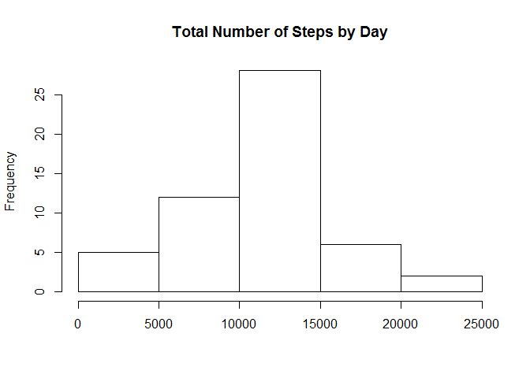

```r
hist(day_data$steps, main = "Total Number of Steps by Day", xlab = "")
```

**3. Mean and median number of steps taken each day**

Mean number of steps per day

```r
mean(day_data$steps, na.rm = TRUE)
```

```
## [1] 10766.19
```

Median number of steps per day.

```r
median(day_data$steps, na.rm = TRUE)
```

```
## [1] 10765
```

**4. Time series plot of the average number of steps taken**

Create subset of data by Mean of Steps per Interval for future use

```r
interval_data <- aggregate(steps ~ interval, data = raw_data, mean, na.action = na.omit)
```

Create Time series plot of the average number of steps taken

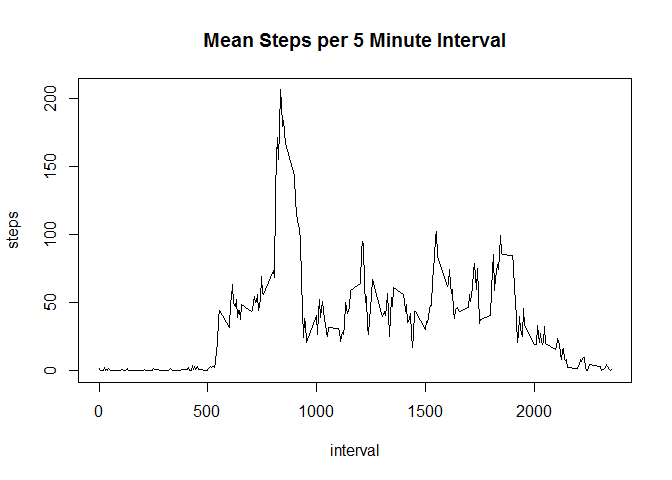

```r
plot(interval_data, type = "l", main = "Mean Steps per 5 Minute Interval")
```

**5. The 5-minute interval that, on average, contains the maximum number of steps**

Find the 5-minute intervals that, on average, contains the maximum number of steps

```r
subset(interval_data, steps == max(interval_data$steps))$interval
```

```
## [1] 835
```

**6. Code to describe and show a strategy for imputing missing data**

Create basic strategy for imputing missing data. Simple strategy will use Median of steps per interval to replace NA data.

```r
## Calculate median number of steps per interval
interval_data_median <- aggregate(steps ~ interval, data = raw_data, median, na.action = na.omit)

## Copy raw_data to preserve it
imputed_data <- raw_data

## Create loop to replace NA values with Median Values

for(i in 1:nrow(imputed_data)){
        if(is.na(imputed_data[i,]$steps)){
                imputed_data[i,]$steps <-
                        interval_data_median[interval_data_median$interval == imputed_data[i,]$interval,]$steps
        }
}

summary(imputed_data)
```

```
##      steps             date          interval
##  Min.   :  0   2012-10-01:  288   Min.   :   0.0
##  1st Qu.:  0   2012-10-02:  288   1st Qu.: 588.8
##  Median :  0   2012-10-03:  288   Median :1177.5
##  Mean   : 33   2012-10-04:  288   Mean   :1177.5
##  3rd Qu.:  8   2012-10-05:  288   3rd Qu.:1766.2
##  Max.   :806   2012-10-06:  288   Max.   :2355.0
##                (Other)   :15840
```

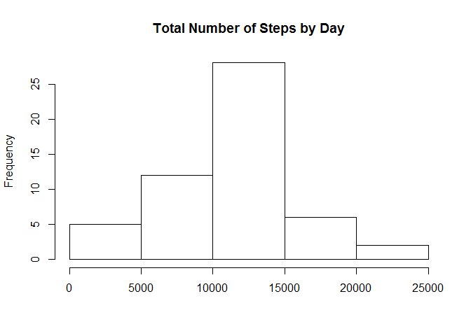

```r
imputed_day_data <- aggregate(steps ~ date, data = raw_data, sum, na.action = na.omit)
hist(imputed_day_data$steps, main = "Total Number of Steps by Day", xlab = "")
```

**8. Panel plot comparing the average number of steps taken per 5-minute interval across weekdays and weekends**

Create panel plot comparing the average number of steps taken per 5-minute interval across weekdays and weekends (using Imputed data)

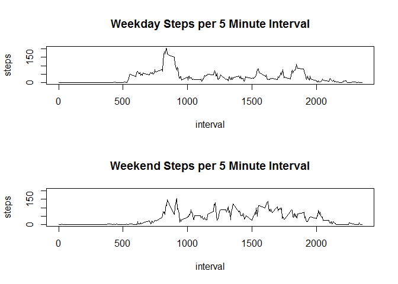

```r
## Classify each date in imputed data as weekday or weekend
for(i in 1:nrow(imputed_data)){
        if(weekdays(as.POSIXlt(imputed_data[i,]$date)) %in% c("Saturday", "Sunday")){
                imputed_data[i,"Week_Day_type"] <- "Weekend"
        }
        else {
              imputed_data[i,"Week_Day_type"] <- "Weekday"
        }
}

# Create data frames per 5 minute intervals for both Weekend and Weekday Data
weekday_interval_data <- aggregate(steps ~ interval, data = subset(imputed_data, imputed_data$Week_Day_type == "Weekday"), mean, na.action = na.omit)

weekend_interval_data <- aggregate(steps ~ interval, data = subset(imputed_data, imputed_data$Week_Day_type == "Weekend"), mean, na.action = na.omit)

#Find the maximum value that must be on the graphs, so that both y axis can be set equally
ymax <- max(weekday_interval_data$steps, weekend_interval_data$steps)

#Create panel plot of findings
par(mfrow = c(2,1))
plot(weekday_interval_data, type = "l", main = "Weekday Steps per 5 Minute Interval", ylim=c(0,ymax))
plot(weekend_interval_data, type = "l", main = "Weekend Steps per 5 Minute Interval", ylim=c(0,ymax))
```

**9. All of the R code needed to reproduce the results (numbers, plots, etc.) in the report**

Code has been included in above segments.